# Practical Machine Learning: Project

Sheila

December 27, 2015

Introduction and Background: Using devices such as Jawbone Up, Nike FuelBand, and Fitbit it is now possible to collect a large amount of data about personal activity relatively inexpensively. These type of devices are part of the quantified self movement - a group of enthusiasts who take measurements about themselves regularly to improve their health, to find patterns in their behavior, or because they are tech geeks. One thing that people regularly do is quantify how much of a particular activity they do, but they rarely quantify how well they do it.

Goal: To use data from accelerometers to predict the manner in which people perform exercise (i.e., response variable is “classe” in the training set).

## 1. Load the required libraries

```r
library(knitr)
library(caret)
library(rattle)
```

```r
library(rpart)
library(rpart.plot)
library(randomForest)
```

## 2. Load the source data

```r
## The training data source was retrieved from location: https://d396qusza40orc.cloudfront.net/predmachlearn/pml-training.csv
trainingRaw<-read.csv("pml-training.csv", header = TRUE)
dim(trainingRaw)
```

```
## [1] 19622   160
```

```r
## The testing data source was retrieved from location: https://d396qusza40orc.cloudfront.net/predmachlearn/pml-testing.csv
testingRaw<-read.csv("pml-testing.csv", header = TRUE)
dim(testingRaw)
```

```
## [1]  20 160
```

## 3. Clean and partition the data

```r
#remove missing values
trainingRaw1<-trainingRaw[,colSums(is.na(trainingRaw))==0]
dim(trainingRaw1)
```

```
## [1] 19622    93
```

```r
testingRaw1<-testingRaw[,colSums(is.na(trainingRaw))==0]
dim(testingRaw1)
```

```
## [1] 20 93
```

```r
#remove near zero values
removeNZV<-nearZeroVar(trainingRaw1,saveMetrics=TRUE)
removeNZV1<-sum(removeNZV$nzv)
if((removeNZV1>0)){
  trainingRaw1<-trainingRaw1[,removeNZV$nzv==FALSE]
}

#remove unnecessary values, i.e., the first 7 columns provide no added value so delete
trainingClean<-trainingRaw1[,-c(1:7)]
dim(trainingClean)
```

```
## [1] 19622    52
```

```r
testingClean<-testingRaw1[,-c(1:7)]
dim(testingClean)
```

```
## [1] 20 86
```

```r
#split the data
set.seed(1234)
inTrain<-createDataPartition(trainingClean$classe,p=0.7,list=FALSE)
inTrainFinal<-trainingClean[inTrain,]
dim(inTrainFinal)
```

```
## [1] 13737    52
```

```r
inTestFinal<-trainingClean[-inTrain,]
dim(inTestFinal)
```

```
## [1] 5885   52
```

## 4. Develop Model

### Classification Tree

```r
modelControl<-trainControl(method="cv", 3)

#Classification Tree
modelTrain<-train(classe~.,data=inTrainFinal,method="rpart",trControl=modelControl)
modelTrain
```

```
## CART
##
## 13737 samples
##    51 predictor
##     5 classes: 'A', 'B', 'C', 'D', 'E'
##
## No pre-processing
## Resampling: Cross-Validated (3 fold)
## Summary of sample sizes: 9157, 9157, 9160
## Resampling results across tuning parameters:
##
##   cp          Accuracy   Kappa       Accuracy SD  Kappa SD
##   0.02960024  0.5524660  0.42921191  0.06718403   0.09300718
##   0.03061743  0.5524660  0.42921191  0.06718403   0.09300718
##   0.03717831  0.3428569  0.09763445  0.10129770   0.16910782
##
## Accuracy was used to select the optimal model using  the largest value.
## The final value used for the model was cp = 0.03061743.
```

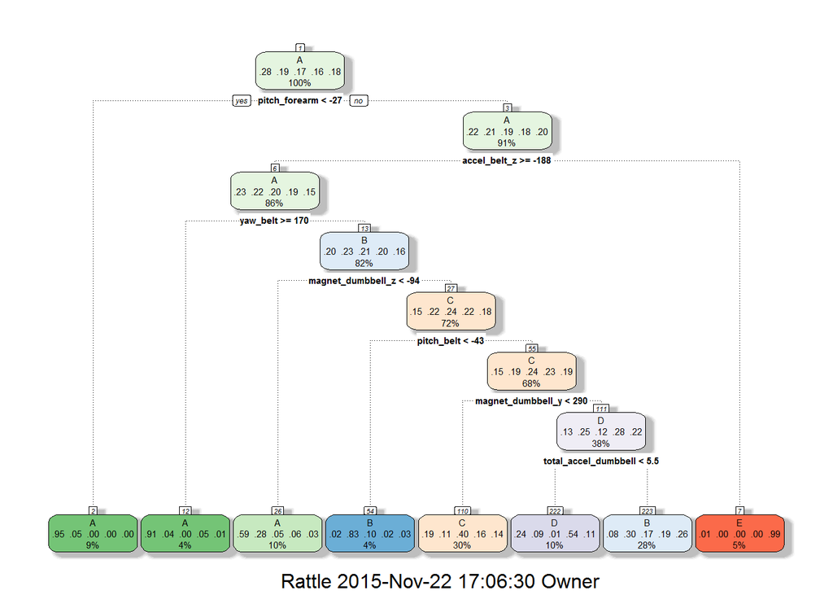

```r
fancyRpartPlot(modelTrain$finalModel)
```

```r
predictRpart<-predict(modelTrain,inTestFinal)
confusionMatrix(inTestFinal$classe,predictRpart)
```

```
## Confusion Matrix and Statistics
##
##           Reference
## Prediction    A    B    C    D    E
##          A 1037  166  322  147    2
##          B  210  682  187   60    0
##          C   30  334  657    5    0
##          D   47  338  283  296    0
##          E   22  443  257   67  293
##
## Overall Statistics
##
##                Accuracy : 0.5038
##                  95% CI : (0.491, 0.5167)
##     No Information Rate : 0.3336
##     P-Value [Acc > NIR] : < 2.2e-16
##
##                   Kappa : 0.3756
##  Mcnemar's Test P-Value : < 2.2e-16
##
## Statistics by Class:
##
##                      Class: A Class: B Class: C Class: D Class: E
## Sensitivity            0.7704   0.3474   0.3851  0.51478  0.99322
## Specificity            0.8597   0.8835   0.9117  0.87420  0.85886
## Pos Pred Value         0.6195   0.5988   0.6404  0.30705  0.27079
## Neg Pred Value         0.9266   0.7301   0.7841  0.94330  0.99958
## Prevalence             0.2287   0.3336   0.2899  0.09771  0.05013
## Detection Rate         0.1762   0.1159   0.1116  0.05030  0.04979
## Detection Prevalence   0.2845   0.1935   0.1743  0.16381  0.18386
## Balanced Accuracy      0.8150   0.6155   0.6484  0.69449  0.92604
```

Classification Tree: comments

-Out-of-Sample error rate is approximately 0.5; given the Accuracy rate is approximately 0.5.

-Classification Tree does not provide a good prediction.

### Random Forest

```r
#Random Forest
modelRF<-train(classe~.,data=inTrainFinal,method="rf",trControl=modelControl)
modelRF
```

```
## Random Forest
##
## 13737 samples
##    51 predictor
##     5 classes: 'A', 'B', 'C', 'D', 'E'
##
## No pre-processing
## Resampling: Cross-Validated (3 fold)
## Summary of sample sizes: 9157, 9158, 9159
## Resampling results across tuning parameters:
##
##   mtry  Accuracy   Kappa      Accuracy SD  Kappa SD
##    2    0.9868965  0.9834204  0.002864973  0.003626109
##   26    0.9883528  0.9852648  0.001637585  0.002072626
##   51    0.9822380  0.9775257  0.001417032  0.001792502
##
## Accuracy was used to select the optimal model using  the largest value.
## The final value used for the model was mtry = 26.
```

```r
predictRF<-predict(modelRF,inTestFinal)
confusionMatrix(inTestFinal$classe,predictRF)
```

```
## Confusion Matrix and Statistics
##
##           Reference
## Prediction    A    B    C    D    E
##          A 1674    0    0    0    0
##          B   11 1127    1    0    0
##          C    0    4 1019    3    0
##          D    0    0    5  957    2
##          E    0    0    1    1 1080
##
## Overall Statistics
##
##                Accuracy : 0.9952
##                  95% CI : (0.9931, 0.9968)
##     No Information Rate : 0.2863
##     P-Value [Acc > NIR] : < 2.2e-16
##
##                   Kappa : 0.994
##  Mcnemar's Test P-Value : NA
##
## Statistics by Class:
##
##                      Class: A Class: B Class: C Class: D Class: E
## Sensitivity            0.9935   0.9965   0.9932   0.9958   0.9982
## Specificity            1.0000   0.9975   0.9986   0.9986   0.9996
## Pos Pred Value         1.0000   0.9895   0.9932   0.9927   0.9982
## Neg Pred Value         0.9974   0.9992   0.9986   0.9992   0.9996
## Prevalence             0.2863   0.1922   0.1743   0.1633   0.1839
## Detection Rate         0.2845   0.1915   0.1732   0.1626   0.1835
## Detection Prevalence   0.2845   0.1935   0.1743   0.1638   0.1839
## Balanced Accuracy      0.9967   0.9970   0.9959   0.9972   0.9989
```

Random Forest: comments

-Out-of-Sample error rate is approximately 0.01; given the Accuracy rate is approximately 0.99.

-Random Forest is much better than the Classification Tree.

## 5. Run Model

Will use the Random Forest to predict the “classe” variable.

```r
runPredictions<-predict(modelRF,testingClean)
runPredictions
```

```
##  [1] B A B A A E D B A A B C B A E E A B B B
## Levels: A B C D E
```

```r
#Function used to generate the test case files

pml_write_files = function(x){
  n = length(x)
  for(i in 1:n){
    filename = paste0("problem_id_",i,".txt")
    write.table(x[i],file=filename,quote=FALSE,row.names=FALSE,col.names=FALSE)
  }
}

pml_write_files(runPredictions)
```